This is a regression analysis of the merged city of Seattle data from Group 6.

First, I will import the data from GitHub and prepare it for use in R:

```r
link = 'https://raw.githubusercontent.com/Group-6-542/EmilyRepository/50e2502dfe3fde3a633f8ca193eb0c6ff76aafe5/mergedGroupDataFinal.csv'
myfile = url(link)
fromPy = read.csv(file = myfile)

# reset indexes to R format:
row.names(fromPy)=NULL
```

```r
#verify data structure
str(fromPy,width = 50,strict.width='cut')
```

```
## 'data.frame':    25 obs. of  6 variables:
##  $ zipcode        : int  98101 98102 98103 98104..
##  $ culturalSpaces : int  55 20 77 87 64 8 35 36 ..
##  $ numberOfReturns: int  7890 15880 28150 6580 1..
##  $ avgAGI         : num  136.1 94.8 85.4 98.7 10..
##  $ casesReported  : int  5361 1752 4053 3513 295..
##  $ numberOfPets   : int  12 29 84 9 47 27 60 25 ..
```

```r
#prepare hypotheses
# hypothesis 1: culturalSpaces increases as avgAGI increases:
hypo1=formula(culturalSpaces~ avgAGI)

# hypothesis 2: casesReported decreases as avgAGI increases:

hypo2=formula(casesReported~ avgAGI)
```

Testing the results.

```r
#
# results
gauss1=glm(hypo1,
           data = fromPy,
           family = 'gaussian')

gauss2=glm(hypo2,
           data = fromPy,
           family = 'gaussian')
```

```r
summary(gauss1)
```

```
##
## Call:
## glm(formula = hypo1, family = "gaussian", data = fromPy)
##
## Deviance Residuals:
##     Min       1Q   Median       3Q      Max
## -25.013  -20.383   -9.394    7.800   58.259
##
## Coefficients:
##             Estimate Std. Error t value Pr(>|t|)
## (Intercept) 25.37128   15.69041   1.617    0.120
## avgAGI       0.05656    0.15631   0.362    0.721
##
## (Dispersion parameter for gaussian family taken to be 691.9325)
##
##     Null deviance: 16005  on 24  degrees of freedom
## Residual deviance: 15914  on 23  degrees of freedom
## AIC: 238.35
##
## Number of Fisher Scoring iterations: 2
```

```r
summary(gauss2)
```

```
##
## Call:
## glm(formula = hypo2, family = "gaussian", data = fromPy)
##
## Deviance Residuals:
##     Min       1Q   Median       3Q      Max
## -1701.2   -794.1   -247.8    732.4   2942.3
##
## Coefficients:
##             Estimate Std. Error t value Pr(>|t|)
## (Intercept) 1467.220    696.130   2.108   0.0462 *
## avgAGI         6.989      6.935   1.008   0.3240
## ---
## Signif. codes:  0 '***' 0.001 '**' 0.01 '*' 0.05 '.' 0.1 ' ' 1
##
## (Dispersion parameter for gaussian family taken to be 1361997)
##
##     Null deviance: 32709225  on 24  degrees of freedom
## Residual deviance: 31325936  on 23  degrees of freedom
## AIC: 427.97
##
## Number of Fisher Scoring iterations: 2
```

```r
library(rsq)
rsq(gauss2,adj=T)
```

```
## [1] 0.0006509673
```

```r
library(rsq)
rsq(gauss1,adj=T)
```

```
## [1] -0.03757197
```

Based on the r-squared, it doesn’t look like either of these models are a good fit.

I’ll try another hypothesis: that the number of pets increases as the number of returns (i.e., the population) increases in a zip code.

```r
# hypo 3 - numberOfPets increases as numberOfReturns increases
hypo3=formula(numberOfPets~ numberOfReturns)
```

```r
gauss3=glm(hypo3,
           data = fromPy,
           family = 'gaussian')
```

```r
summary(gauss3)
```

```
##
## Call:
## glm(formula = hypo3, family = "gaussian", data = fromPy)
##
## Deviance Residuals:
##     Min       1Q   Median       3Q      Max
## -27.143   -5.522   -0.826    6.170   37.829
##
## Coefficients:
##                   Estimate Std. Error t value Pr(>|t|)
## (Intercept)     -3.6668865  7.2496658  -0.506    0.618
## numberOfReturns  0.0028951  0.0004594   6.303 1.97e-06 ***
## ---
## Signif. codes:  0 '***' 0.001 '**' 0.01 '*' 0.05 '.' 0.1 ' ' 1
##
## (Dispersion parameter for gaussian family taken to be 200.1851)
##
##     Null deviance: 12556.0  on 24  degrees of freedom
## Residual deviance:  4604.3  on 23  degrees of freedom
## AIC: 207.34
##
## Number of Fisher Scoring iterations: 2
```

```r
library(rsq)
rsq(gauss3,adj=T)
```

```
## [1] 0.6173589
```

Based on the r-squared, this is a better model.

I’ll try another hypothesis: that the number of pets increases as the average AGI increases.

```r
# hypo 4 - numberOfPets increases as avgAGI increases
hypo4=formula(numberOfPets~ avgAGI)
```

```r
gauss4=glm(hypo4,
           data = fromPy,
           family = 'gaussian')
```

```r
summary(gauss4)
```

```
##
## Call:
## glm(formula = hypo4, family = "gaussian", data = fromPy)
##
## Deviance Residuals:
##     Min       1Q   Median       3Q      Max
## -35.451  -16.318   -2.386   10.142   46.532
##
## Coefficients:
##             Estimate Std. Error t value Pr(>|t|)
## (Intercept)  48.8536    13.7434   3.555  0.00169 **
## avgAGI       -0.1105     0.1369  -0.807  0.42773
## ---
## Signif. codes:  0 '***' 0.001 '**' 0.01 '*' 0.05 '.' 0.1 ' ' 1
##
## (Dispersion parameter for gaussian family taken to be 530.868)
##
##     Null deviance: 12556  on 24  degrees of freedom
## Residual deviance: 12210  on 23  degrees of freedom
## AIC: 231.73
##
## Number of Fisher Scoring iterations: 2
```

```r
library(rsq)
rsq(gauss4,adj=T)
```

```
## [1] -0.01472064
```

This doesn’t look like a very good model. I will test to see which one is better:

```r
anova(gauss3,gauss4,test="Chisq")
```

```
## Analysis of Deviance Table
##
## Model 1: numberOfPets ~ numberOfReturns
## Model 2: numberOfPets ~ avgAGI
##   Resid. Df Resid. Dev Df Deviance Pr(>Chi)
## 1        23     4604.3
## 2        23    12210.0  0  -7605.7
```

The model for hypothesis 3 is the better model. Next I will plot it:

```r
library(dotwhisker)
```

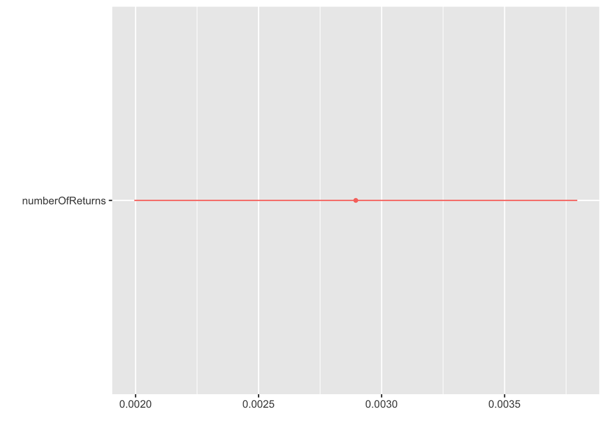

```r
dwplot(gauss3)
```

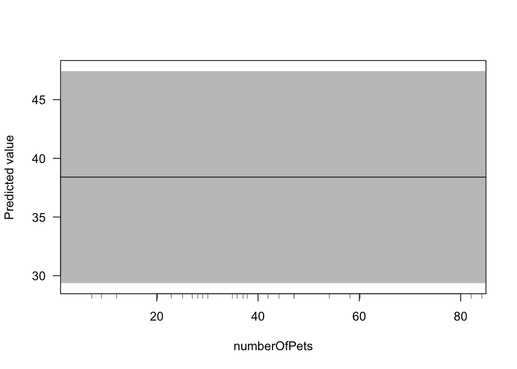

```r
library(margins)
cplot(gauss4,'numberOfPets')
```

I will see if I can create a better fitting model by using one more variable in my hypothesis. My next hypothesis is that as the number of pets increases, the number of returns and the number of cultural spaces increases:

```r
hypo5=formula(numberOfPets~ numberOfReturns * culturalSpaces)
```

```r
gauss5=glm(hypo5,
           data = fromPy,
           family = 'gaussian')
```

```r
summary(gauss5)
```

```
##
## Call:
## glm(formula = hypo5, family = "gaussian", data = fromPy)
##
## Deviance Residuals:
##     Min       1Q   Median       3Q      Max
## -27.386   -5.422   -1.503    5.620   39.518
##
## Coefficients:
##                                  Estimate Std. Error t value Pr(>|t|)
## (Intercept)                     4.095e+00  1.254e+01   0.327   0.7472
## numberOfReturns                 2.322e-03  8.027e-04   2.893   0.0087 **
## culturalSpaces                 -1.991e-01  2.830e-01  -0.703   0.4896
## numberOfReturns:culturalSpaces  1.447e-05  1.666e-05   0.869   0.3949
## ---
## Signif. codes:  0 '***' 0.001 '**' 0.01 '*' 0.05 '.' 0.1 ' ' 1
##
## (Dispersion parameter for gaussian family taken to be 211.1784)
##
##     Null deviance: 12556.0  on 24  degrees of freedom
## Residual deviance:  4434.7  on 21  degrees of freedom
## AIC: 210.41
##
## Number of Fisher Scoring iterations: 2
```

```r
library(rsq)
rsq(gauss5,adj=T)
```

```
## [1] 0.5963459
```

This doesn’t seem to improve the model that much, but I will test:

```r
anova(gauss3,gauss5,test="Chisq")
```

```
## Analysis of Deviance Table
##
## Model 1: numberOfPets ~ numberOfReturns
## Model 2: numberOfPets ~ numberOfReturns * culturalSpaces
##   Resid. Df Resid. Dev Df Deviance Pr(>Chi)
## 1        23     4604.3
## 2        21     4434.7  2   169.51   0.6694
```

Hypo 3 is still the better model.

Now I’ll test this model as if it had a binary dependent variable. I need to create one:

```r
#Binary outcome

fromPy$numberOfReturnsdico=ifelse(fromPy$numberOfReturns>median(fromPy$numberOfReturns,
                                        na.rm = T),
                      1,0)
```

```r
hypoDico1=formula(numberOfReturnsdico~ numberOfPets)
```

```r
fromPy$numberOfReturnsdico=factor(fromPy$numberOfReturnsdico)
```

```r
Logi1=glm(hypoDico1,data = fromPy,
          family = "binomial")
```

```r
summary(Logi1)
```

```
##
## Call:
## glm(formula = hypoDico1, family = "binomial", data = fromPy)
##
## Deviance Residuals:
##      Min        1Q    Median        3Q       Max
## -1.69477  -0.49694  -0.06816   0.33609   1.78103
##
## Coefficients:
##              Estimate Std. Error z value Pr(>|z|)
## (Intercept)  -6.23181    2.65565  -2.347   0.0189 *
## numberOfPets  0.16810    0.07185   2.340   0.0193 *
## ---
## Signif. codes:  0 '***' 0.001 '**' 0.01 '*' 0.05 '.' 0.1 ' ' 1
##
## (Dispersion parameter for binomial family taken to be 1)
##
##     Null deviance: 34.617  on 24  degrees of freedom
## Residual deviance: 16.474  on 23  degrees of freedom
## AIC: 20.474
##
## Number of Fisher Scoring iterations: 6
```

```r
library(margins)
(marginsINFO = margins(Logi1))
```

```
## Average marginal effects
```

```
## glm(formula = hypoDico1, family = "binomial", data = fromPy)
```

```
##  numberOfPets
##       0.01771
```

```r
(marginsSUMM=summary(marginsINFO))
```

```
##        factor    AME     SE      z      p  lower  upper
##  numberOfPets 0.0177 0.0022 7.9451 0.0000 0.0133 0.0221
```

```r
fromPy$numberOfPetsdico=ifelse(fromPy$numberOfPets>median(fromPy$numberOfPets,
                                        na.rm = T),
                      1,0)
```

Next I will try the hypothesis 5, where I added the cultural spaces variable.

```r
hypoDico2=formula(numberOfPetsdico~ numberOfReturns * culturalSpaces)
```

```r
Logi2=glm(hypoDico2,data = fromPy,
          family = "binomial")
```

```r
summary(Logi2)
```

```
##
## Call:
## glm(formula = hypoDico2, family = "binomial", data = fromPy)
##
## Deviance Residuals:
##     Min       1Q   Median       3Q      Max
## -2.3817  -0.8183  -0.1504   0.8340   1.7794
##
## Coefficients:
##                                  Estimate Std. Error z value Pr(>|z|)
## (Intercept)                    -4.641e+00  2.980e+00  -1.557    0.119
## numberOfReturns                 2.896e-04  2.022e-04   1.433    0.152
## culturalSpaces                 -9.323e-04  7.182e-02  -0.013    0.990
## numberOfReturns:culturalSpaces  1.133e-06  5.039e-06   0.225    0.822
##
## (Dispersion parameter for binomial family taken to be 1)
##
##     Null deviance: 34.617  on 24  degrees of freedom
## Residual deviance: 23.278  on 21  degrees of freedom
## AIC: 31.278
##
## Number of Fisher Scoring iterations: 6
```

I will test which model is better:

```r
library("lmtest")
lmtest::lrtest(Logi1,Logi2)
```

```
## Likelihood ratio test
##
## Model 1: numberOfReturnsdico ~ numberOfPets
## Model 2: numberOfPetsdico ~ numberOfReturns * culturalSpaces
##   #Df   LogLik Df  Chisq Pr(>Chisq)
## 1   2  -8.2372
## 2   4 -11.6388  2 6.8033    0.03332 *
## ---
## Signif. codes:  0 '***' 0.001 '**' 0.01 '*' 0.05 '.' 0.1 ' ' 1
```

I will test another model, where number of pets increases as number of returns increases:

```r
fromPy$numberOfPetsdico=ifelse(fromPy$numberOfPets>median(fromPy$numberOfPets,
                                        na.rm = T),
                      1,0)
```

```r
hypoDico3=formula(numberOfPetsdico~ numberOfReturns)
```

```r
Logi3=glm(hypoDico3,data = fromPy,
          family = "binomial")
```

```r
lmtest::lrtest(Logi2,Logi3)
```

```
## Likelihood ratio test
##
## Model 1: numberOfPetsdico ~ numberOfReturns * culturalSpaces
## Model 2: numberOfPetsdico ~ numberOfReturns
##   #Df  LogLik Df  Chisq Pr(>Chisq)
## 1   4 -11.639
## 2   2 -11.852 -2 0.4261     0.8081
```

The number of pets to number of returns model is still the best fit. Let’s test one last model. The hypothesis is that the number of pets increases as the number of returns and the average AGI increases:

```r
hypoDico4=formula(numberOfPetsdico~ numberOfReturns * avgAGI)
```

```r
Logi4=glm(hypoDico4,data = fromPy,
          family = "binomial")
```

```r
summary(Logi4)
```

```
##
## Call:
## glm(formula = hypoDico4, family = "binomial", data = fromPy)
##
## Deviance Residuals:
##      Min        1Q    Median        3Q       Max
## -1.81230  -0.70841  -0.00428   0.58618   1.95195
##
## Coefficients:
##                          Estimate Std. Error z value Pr(>|z|)
## (Intercept)             3.902e+00  6.531e+00   0.597    0.550
## numberOfReturns        -4.523e-04  4.969e-04  -0.910    0.363
## avgAGI                 -1.294e-01  9.483e-02  -1.364    0.172
## numberOfReturns:avgAGI  1.127e-05  7.591e-06   1.485    0.138
##
## (Dispersion parameter for binomial family taken to be 1)
##
##     Null deviance: 34.617  on 24  degrees of freedom
## Residual deviance: 20.212  on 21  degrees of freedom
## AIC: 28.212
##
## Number of Fisher Scoring iterations: 6
```

I will compare it to the model that includes the number of cultural spaces.

```r
lmtest::lrtest(Logi2,Logi4)
```

```
## Likelihood ratio test
##
## Model 1: numberOfPetsdico ~ numberOfReturns * culturalSpaces
## Model 2: numberOfPetsdico ~ numberOfReturns * avgAGI
##   #Df  LogLik Df  Chisq Pr(>Chisq)
## 1   4 -11.639
## 2   4 -10.106  0 3.0654  < 2.2e-16 ***
## ---
## Signif. codes:  0 '***' 0.001 '**' 0.01 '*' 0.05 '.' 0.1 ' ' 1
```

Model 4 is the better fit.

```r
library(margins)
(marginsINFO = margins(Logi4))
```

```
## Average marginal effects
```

```
## glm(formula = hypoDico4, family = "binomial", data = fromPy)
```

```
##  numberOfReturns   avgAGI
##        7.375e-05 0.005598
```

```r
(marginsSUMM=summary(marginsINFO))
```

```
##           factor    AME     SE      z      p   lower  upper
##           avgAGI 0.0056 0.0033 1.7164 0.0861 -0.0008 0.0120
##  numberOfReturns 0.0001 0.0000 4.3129 0.0000  0.0000 0.0001
```

Now I’ll plot it:

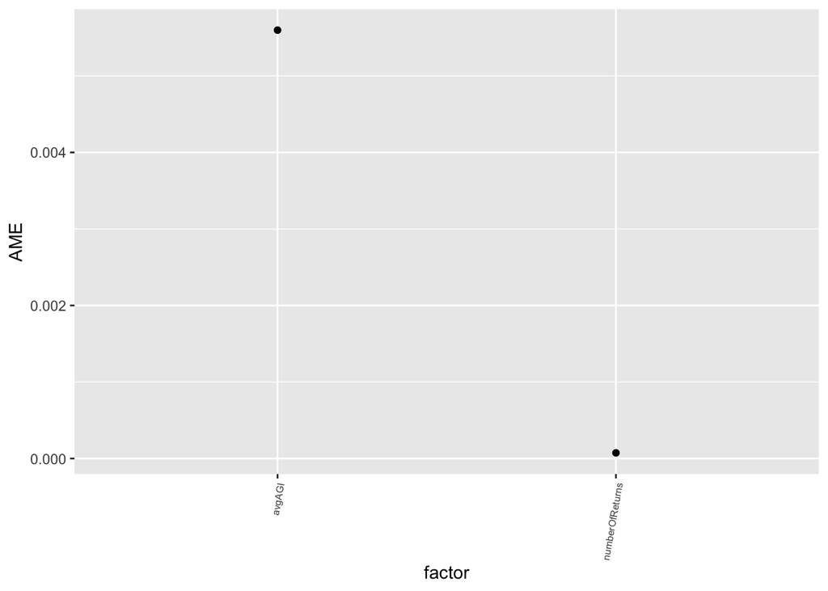

```r
base= ggplot(marginsSUMM,
             aes(x=factor, y=AME))
base= base + geom_point()

plotMargins = base + theme(axis.text.x = element_text(angle = 80,size = 6,hjust = 1))
plotMargins
```

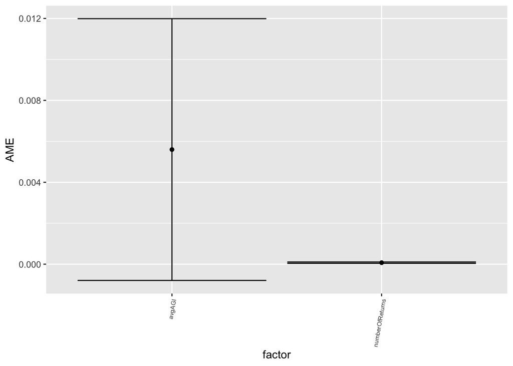

```r
plotMargins +  geom_errorbar(aes(ymin=lower,
                                 ymax=upper))
```

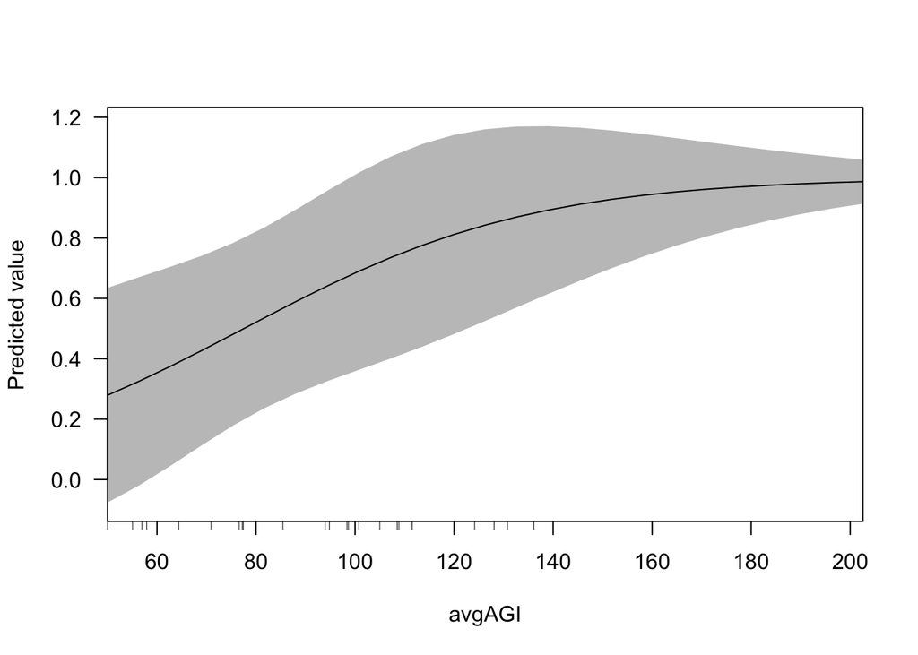

```r
cplot(Logi4, "avgAGI")
```

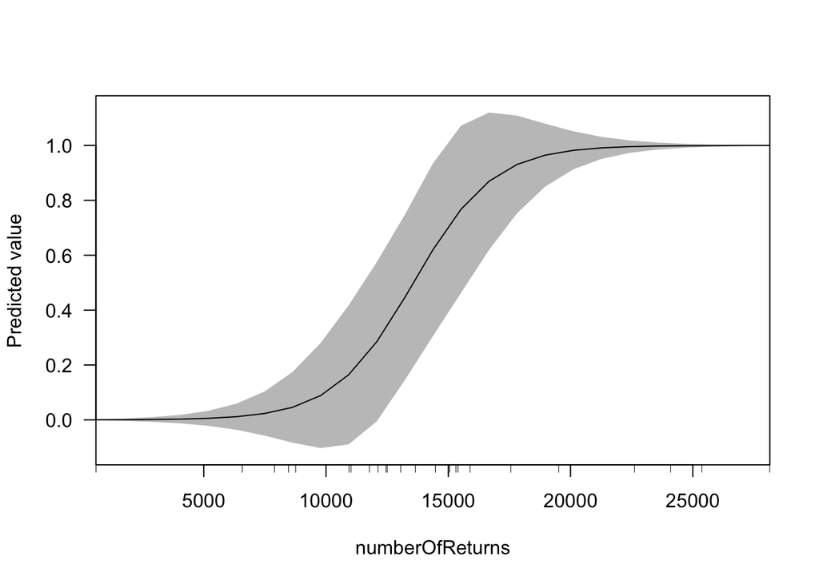

```r
cplot(Logi4, "numberOfReturns")
```

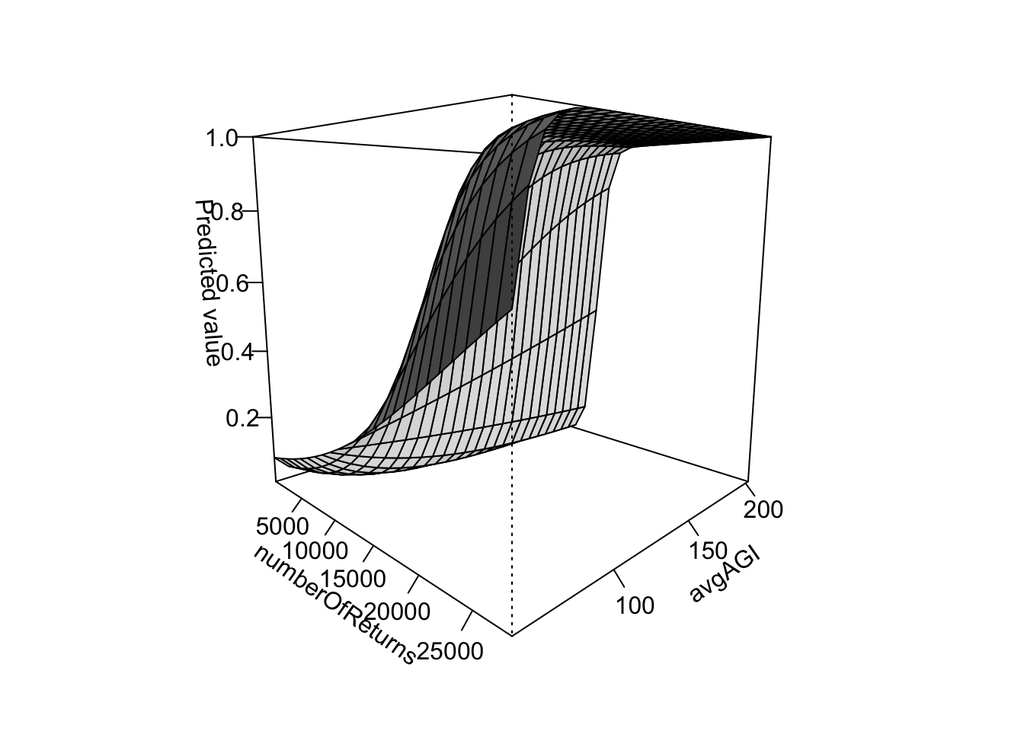

```r
persp(Logi4)
```

```r
options(repos="https://cran.rstudio.com" )
```